# Future Sales Prediction and Analysis

107071034 許亦晴 & 107071008 陳昭維

2021/6/27

#資料結構 #模型運用

**自 Kaggle 網站中獲取五種資料檔，包含店舖、產品種類、品名等每日銷售資料。利用過去資料（2013/01/01~ 2015/09/31）經過進行資料整合後，利用不同方法做後期模擬、與估計，最終預測出未來（2015/10）之月銷售量，與該月實際資料進行比較，找出其中最適結果，並分析檢討該結果。**

# 一、資料分析

## (一) 匯入資料

首先利用套件readr讀取自網站中下載好的資料，觀察資料的格式和內容。

```r
library(GGally)
library(tidyverse)
library(readr)
library(knitr)

df_train = read.csv('/Users/venessa/Downloads/competitive-data-science-predict-future-sales/sales_train.csv')
df_test = read.csv('/Users/venessa/Downloads/competitive-data-science-predict-future-sales/test.csv')
items = read.csv('/Users/venessa/Downloads/competitive-data-science-predict-future-sales/items.csv')

kable(head(df_train))
```

| date | date_block_num | shop_id | item_id | item_price | item_cnt_day |
| --- | --- | --- | --- | --- | --- |
| 02.01.2013 | 0 | 59 | 22154 | 999.00 | 1 |
| 03.01.2013 | 0 | 25 | 2552 | 899.00 | 1 |
| 05.01.2013 | 0 | 25 | 2552 | 899.00 | -1 |
| 06.01.2013 | 0 | 25 | 2554 | 1709.05 | 1 |
| 15.01.2013 | 0 | 25 | 2555 | 1099.00 | 1 |
| 10.01.2013 | 0 | 25 | 2564 | 349.00 | 1 |

```r
kable(head(df_test))
```

| ID | shop_id | item_id |
| --- | --- | --- |
| 0 | 5 | 5037 |
| 1 | 5 | 5320 |
| 2 | 5 | 5233 |
| 3 | 5 | 5232 |
| 4 | 5 | 5268 |
| 5 | 5 | 5039 |

## (二) 資料合併及時間資料處理

利用課程中教過的dplyr搭配magritter合併整理橫斷面資料。由於最後僅需預測月銷量，因此需另外自日銷量轉換及計算，其中利用lubridate來處理時間資料。

```r
library(magrittr)
library(dplyr)
library(tidyr)
library(purrr)
item_data = items %>% right_join(df_test)%>%
  transmute( ID= ID,
             shop_id = shop_id,
             category_id = item_category_id,
             item_id = item_id)

all_data = df_train %>% right_join(item_data) #合併資料
all_data = all_data %>% arrange(date,ID,shop_id,category_id,item_id) #按date,shop_id,item_id小到大排序

##資料格式整理－時間資料格式
library(lubridate)
month_data = all_data %>% mutate(
  date = as.Date(date, format="%d.%m.%Y"),
  month = format(date, "%Y-%m"),
  m = month(date),
  y = year(date)
)

##統整資料格式－計算月銷量、平均售價
demand = month_data %>%
  group_by(month, ID) %>%
  summarise(
    shop_id = mean(shop_id),
    category_id = mean(category_id),
    item_id = mean(item_id),
    price = mean(item_price, na.rm = TRUE),
    month_sales = sum(item_cnt_day, na.rm = TRUE)
  )
kable(head(demand))
```

| month | ID | shop_id | category_id | item_id | price | month_sales |
| --- | --- | --- | --- | --- | --- | --- |
| 2013-01 | 5122 | 4 | 35 | 5823 | 2500.00 | 1 |
| 2013-01 | 5127 | 4 | 2 | 5643 | 2330.25 | 3 |
| 2013-01 | 5142 | 4 | 35 | 5821 | 599.00 | 2 |
| 2013-01 | 5143 | 4 | 35 | 5822 | 999.00 | 9 |
| 2013-01 | 5152 | 4 | 55 | 5459 | 299.00 | 1 |
| 2013-01 | 5169 | 4 | 19 | 3686 | 899.00 | 4 |

## (三) 轉換資料格式

利用pivot_wider( )將資料調至符合模型，使每個商品皆有其對應的月銷量，其運行方式如下。

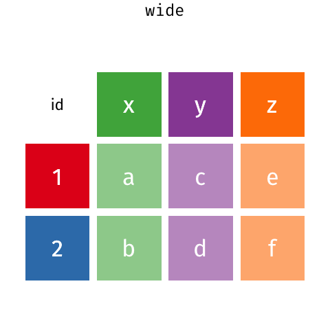

```r
sales_data = demand %>% pivot_wider(id_cols = ID, names_from = month, values_from = month_sales)%>% arrange(ID)
```

由於上述方法使每個商品皆有其對應的月銷量，因此會產生缺漏值。此處未提供之資料視為並未售出，故以銷量=0代入。

```r
sales_pivot = mutate_all(sales_data, ~replace(., is.na(.), 0)) %>% select(-'NA') #缺漏值處理(代入0)
df1 = item_data %>% full_join(sales_pivot)
df2 = df1 %>% pivot_longer(-c(ID,shop_id,category_id,item_id),
                           names_to = "month",
                           values_to = "sales")
```

## (四) 基礎資料分析呈現

先觀察最後整理出的資料結果，可利用pivot_longer( )與pivot_wider( )將df1、df2輕易進行轉換，再利用課程所教之ggplot2進行簡易的繪圖。

```r
library(ggplot2)
kable(df1[c(1:5),c(1:7)])
```

| ID | shop_id | category_id | item_id | 2013-01 | 2013-02 | 2013-03 |
| --- | --- | --- | --- | --- | --- | --- |
| 2587 | 5 | 40 | 30 | 0 | 5 | 7 |
| 7687 | 4 | 40 | 30 | 0 | 7 | 3 |
| 12787 | 6 | 40 | 30 | 0 | 28 | 10 |
| 17887 | 3 | 40 | 30 | 0 | 4 | 5 |
| 22987 | 2 | 40 | 30 | 0 | 0 | 1 |

```r
kable(head(df2))
```

| ID | shop_id | category_id | item_id | month | sales |
| --- | --- | --- | --- | --- | --- |
| 2587 | 5 | 40 | 30 | 2013-01 | 0 |
| 2587 | 5 | 40 | 30 | 2013-02 | 5 |
| 2587 | 5 | 40 | 30 | 2013-03 | 7 |
| 2587 | 5 | 40 | 30 | 2013-04 | 1 |
| 2587 | 5 | 40 | 30 | 2013-05 | 0 |
| 2587 | 5 | 40 | 30 | 2013-06 | 0 |

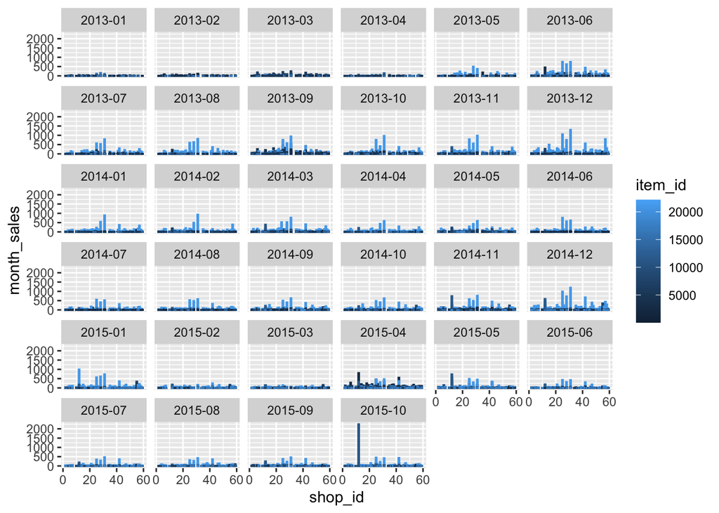

```r
demand %>% drop_na(month) %>%
  ggplot +
  geom_bar(aes(x = shop_id,y = month_sales, color = item_id),position = "dodge",stat="identity")+
  facet_wrap(~ month)
```

**圖一：每月每間店銷量，隨店名排列(依月份分組) =>可比較各店該月總體銷量**

從圖中可大約看出2013年前3至4個月整體銷量皆較少且無個別較高值，推測應為整體市場環境問題所造成，而2015-10有一筆資料明顯較高。 另外銷量較高之店家多為店號中間者（如25至31），此趨勢在下圖個別店家資料亦可觀察出。

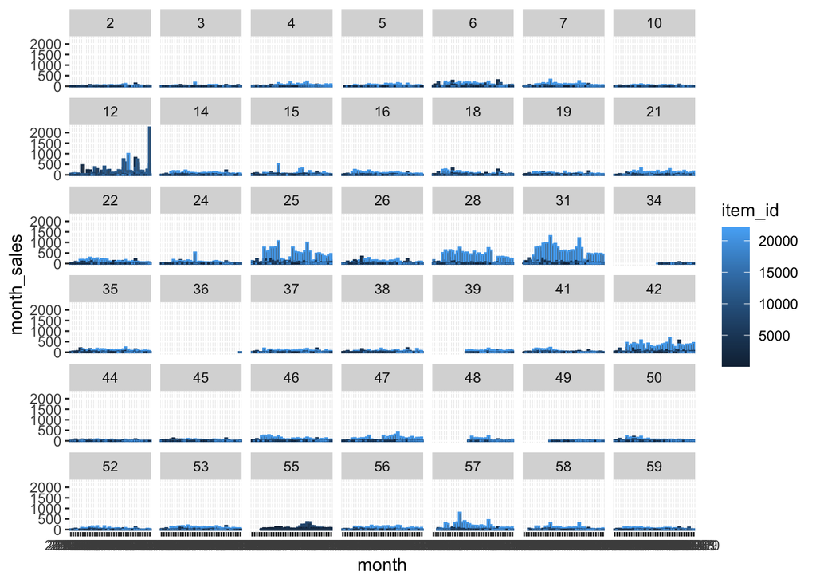

```r
demand %>% drop_na(month) %>%
  ggplot +
  geom_bar(aes(x = month,y = month_sales, color = item_id),position = "dodge",stat="identity")+
  facet_wrap(~ shop_id)
```

**圖二：每間店月銷量，隨時間排列(依店家分組) =>可看出哪家店整體銷量較好、各店淡旺季**

根據此圖可看出在2013/01/01~ 2015/09/31這段期間內，約中間為各店之淡季，銷量較低，可進一步將資料以年為劃分，了解每年趨勢。 此外，個別店舖（12、25、28、31、42）營業額較高，可能原因為該店所選地段較佳、或該店規模本身較大。 與圖（一）搭配觀察可得出2015-10該極端值應為店號12之店家，且該店銷量波動較大，應進一步了解。

# 二、模型設定與分析

首先利用caTools套件中的sample.split( )將資料以8:2的比例隨機分為模型訓練部分(train)以及最終測試部分(test)。同時透過set.seed( )使每次抽樣結果相同。以下利用三個模型皆利用相同的訓練資料進行模型架設，並以相同測試資料預測結果。另外以下皆排除ID資料，以店舖、種類、品項及月銷量進行運算。

## (一) Multiple Linear Regression

### 1.模型設定

```r
##依比例將資料分成train,test
library(caTools)
set.seed(123)
split = sample.split(df1, SplitRatio = 0.8)
train = subset.data.frame(df1,split == TRUE)
test = subset.data.frame(df1,split == FALSE)

x_train = train %>% select(-`2015-10`)
y_train = train %>% select(ID:item_id,`2015-10`)
x_test = test %>% select(-`2015-10`)
y_test = test %>% select(ID:item_id,`2015-10`)
```

### 2.模型運算

利用summary( )即可得出各個變量在此模型下的運算結果。

```r
Regressor1 = lm(`2015-10`~.-ID, data = train) #ID那行不算

#Multiple Linear Regression-運算結果
summary1 = summary(Regressor1)
summary1
```

```
##
## Call:
## lm(formula = `2015-10` ~ . - ID, data = train)
##
## Residuals:
##     Min      1Q  Median      3Q     Max
## -87.638  -0.130  -0.089  -0.044 165.887
##
## Coefficients:
##               Estimate Std. Error t value Pr(>|t|)
## (Intercept)  1.253e-01  1.229e-02  10.197  < 2e-16 ***
## shop_id     -2.489e-04  1.919e-04  -1.297  0.19476
## category_id -1.482e-03  2.097e-04  -7.067 1.59e-12 ***
## item_id      3.472e-06  5.591e-07   6.210 5.32e-10 ***
## `2013-01`   -1.858e-03  3.693e-03  -0.503  0.61499
## `2013-02`   -7.938e-03  3.614e-03  -2.196  0.02806 *
## `2013-03`   -6.899e-03  2.566e-03  -2.689  0.00717 **
## `2013-04`    4.488e-02  5.653e-03   7.939 2.06e-15 ***
## `2013-05`   -8.042e-02  3.432e-03 -23.431  < 2e-16 ***
## `2013-06`   -5.165e-03  2.567e-03  -2.012  0.04423 *
## `2013-07`    1.052e-02  3.994e-03   2.633  0.00847 **
## `2013-08`    2.653e-02  3.175e-03   8.355  < 2e-16 ***
## `2013-09`   -2.684e-02  1.564e-03 -17.158  < 2e-16 ***
## `2013-10`    6.229e-02  2.767e-03  22.512  < 2e-16 ***
## `2013-11`    5.683e-02  2.516e-03  22.588  < 2e-16 ***
## `2013-12`    1.132e-02  1.981e-03   5.716 1.09e-08 ***
## `2014-01`   -4.811e-02  3.984e-03 -12.076  < 2e-16 ***
## `2014-02`   -4.574e-02  3.395e-03 -13.472  < 2e-16 ***
## `2014-03`   -2.439e-02  2.084e-03 -11.702  < 2e-16 ***
## `2014-04`   -1.155e-02  3.830e-03  -3.016  0.00256 **
## `2014-05`    1.774e-02  2.534e-03   7.003 2.52e-12 ***
## `2014-06`    2.495e-02  3.471e-03   7.189 6.55e-13 ***
## `2014-07`    3.769e-02  3.651e-03  10.326  < 2e-16 ***
## `2014-08`   -2.518e-02  3.559e-03  -7.077 1.48e-12 ***
## `2014-09`   -5.870e-02  3.096e-03 -18.959  < 2e-16 ***
## `2014-10`   -8.262e-02  2.965e-03 -27.869  < 2e-16 ***
## `2014-11`   -4.644e-02  1.717e-03 -27.052  < 2e-16 ***
## `2014-12`    5.007e-02  2.172e-03  23.055  < 2e-16 ***
## `2015-01`    3.611e-01  1.620e-03 222.845  < 2e-16 ***
## `2015-02`   -9.217e-02  3.096e-03 -29.765  < 2e-16 ***
## `2015-03`   -1.701e-02  2.771e-03  -6.140 8.28e-10 ***
## `2015-04`    5.777e-03  1.014e-03   5.700 1.20e-08 ***
## `2015-05`    2.600e-02  1.835e-03  14.166  < 2e-16 ***
## `2015-06`   -3.531e-02  4.118e-03  -8.576  < 2e-16 ***
## `2015-07`    4.225e-02  4.343e-03   9.730  < 2e-16 ***
## `2015-08`    1.347e-01  3.604e-03  37.379  < 2e-16 ***
## `2015-09`    2.943e-01  2.494e-03 118.009  < 2e-16 ***
## ---
## Signif. codes:  0 '***' 0.001 '**' 0.01 '*' 0.05 '.' 0.1 ' ' 1
##
## Residual standard error: 1.382 on 169067 degrees of freedom
## Multiple R-squared:  0.7139, Adjusted R-squared:  0.7139
## F-statistic: 1.172e+04 on 36 and 169067 DF,  p-value: < 2.2e-16
```

```r
Result1 = y_train %>%
  transmute(
    ID = ID,
    reality = `2015-10`,
    y_hat = predict(Regressor1, x_train),
    residual = y_hat - reality,
    residual_square = residual^2)

R_square1 = summary(Regressor1)$adj.r.squared
R_square1
```

```
## [1] 0.7138867
```

```r
SStot1 = sum((Result1$y_hat - mean(Result1$reality))^2)
SSresid1 = sum(Result1$residual_square)
#sprintf("percent variance explained, R^2: %1.1f%%", 100 * (1 - SSresid1 / SStot1))
```

得出R平方值為0.7139，且觀察各個變量之p-value可發現其中以2015-01的變量最為顯著，2013-01的變量最不顯著。同時我們可利用vip套件將較為顯著之變量呈現出來。

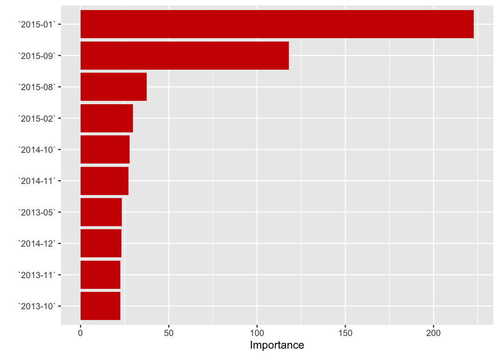

```r
library(vip)
vip(Regressor1,aesthetics = list(fill = "red3"))#繪出權重
```

```r
Result1 = y_train %>%
  transmute(
    ID = ID,
    reality = `2015-10`,
    y_hat = predict(Regressor1, x_train),
    residual = y_hat - reality,
    residual_square = residual^2)
SStot1 = sum((Result1$y_hat - mean(Result1$reality))^2)
SSresid1 = sum(Result1$residual_square)
R_square1 = summary(Regressor1)$adj.r.squared
R_square1
```

```
## [1] 0.7138867
```

```r
#sprintf("percent variance explained, R^2: %1.1f%%", 100 * (1 - SSresid1 / SStot1))
```

### 3.模型檢定

1. 虛無假設H0 = 殘差服從常態分配，執行結果：拒絕虛無假設。

```r
library(car)
##常態假設檢定
Normal = shapiro.test(sample(Regressor1$residual,5000,replace=F))
Normal
```

```
##
##  Shapiro-Wilk normality test
##
## data:  sample(Regressor1$residual, 5000, replace = F)
## W = 0.20642, p-value < 2.2e-16
```

2. 虛無假設H0 = 殘差間相互獨立，執行結果：拒絕虛無假設，表示每個殘差值間具有關聯性。值得注意的是此「自動相關」(autocorrelation)的現象多出現於時間數列資料中。

```r
##獨立性假設-使用car套件
DW = durbinWatsonTest(Regressor1)
DW # 因為這個函式會自動去抓模型中的殘差，故這裡放的是模型，而不是殘差的值
```

```
##  lag Autocorrelation D-W Statistic p-value
##    1       0.3339431      1.332113       0
##  Alternative hypothesis: rho != 0
```

3. 虛無假設H0 = 殘差變異數具有同質性，執行結果：拒絕虛無假設。

```r
##變異數同質性假設-使用car套件
Homogeneity = ncvTest(Regressor1)
Homogeneity
```

```
## Non-constant Variance Score Test
## Variance formula: ~ fitted.values
## Chisquare = 11797857, Df = 1, p = < 2.22e-16
```

由此看出雖模型設定結果尚可，然而以上三者特性p-value皆極小，拒絕虛無假設，資料本身特性並未符合該回歸假設，應更換其他模型進行計算，這邊仍先進行預測以進行最終的比較。

### 4.預測結果

繪出2015-10實際資料與預測資料之比較，紅色為預測結果，藍綠色為實際結果。

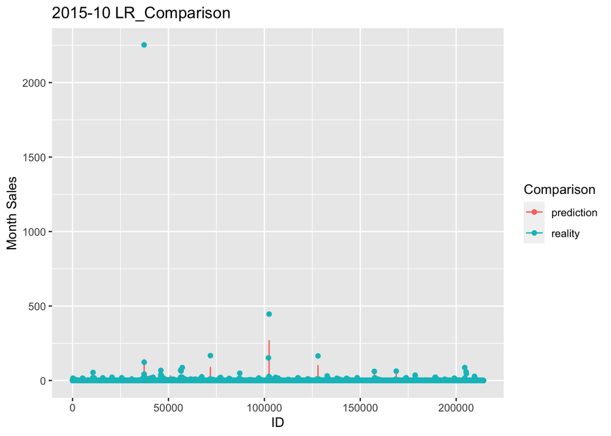

```r
Predict1 = y_test %>%
  transmute(
    ID = ID,
    reality = `2015-10`,
    y_hat = predict(Regressor1, x_test)
    )

library(caret)
MSE1 = mean((Predict1$reality - Predict1$y_hat)^2)
MAE1 = MAE(Predict1$reality, Predict1$y_hat)
RMSE1 = RMSE(Predict1$reality, Predict1$y_hat)

#預測結果呈現：2015-10實際資料與預測資料
ggplot(Predict1, aes(x= ID))+
  geom_line(aes(y = y_hat,colour = "prediction"))+
  geom_point(aes(y = reality,colour = "reality"))+
  labs(title = "2015-10 LR_Comparison",y = "Month Sales",colour = "Comparison")
```

## (二) Light Gradient Boosting Machine

LightGBM 利用 histogram 演算法將連續特徵值分段為 discrete bins 來達到快速訓練並減少記憶體的使用。而他也透過Leaf-wise (Best-first) 的決策樹生長策略，選取delta loss最大 的節點來生長可以減少更多損失，最後再用 max_depth 來限制樹的深度便可並避免過擬合。

### 1.資料格式轉換

將資料轉換成模型所需的lgb.Dataset。

```r
library(data.table)
library(Matrix)
library(lightgbm)
library(Metrics)
ID = 'id'
TARGET = 'loss'
SEED = 0

d1 = x_train %>% select(-ID)
d2 = x_test %>% select(-ID)
y1 = train %>% select(`2015-10`)
y2 = test %>% select(`2015-10`)

yy_train = vector("list", nrow(y1))
for (i in 1:nrow(y1)) {
  yy_train[[i]] <- y1[i,]
}
yy_train = as.numeric(unlist(yy_train))

yy_test = vector("list", nrow(y2))
for (i in 1:nrow(y2)) {
  yy_test[[i]] <- y2[i,]
}
yy_test = as.numeric(unlist(yy_test))

# lightgbm comes with an own sparse matrix format
lgb.dtrain = lgb.Dataset(data = as.matrix(d1), label = yy_train)
lgb.dtest = lgb.Dataset(data = as.matrix(d2), label = yy_test)
```

### 2.模型運算

套入default模型進行比較

```r
# Default-Model:
Regressor2 = lightgbm(boosting_type = 'gbdt', objective = "regression", metric = 'rmse', lgb.dtrain, nrounds = 1000)
```

[output not shown]

[output cut: 991 more lines]

```r
Result2 = y_train %>%
  transmute(
    ID = ID,
    reality = `2015-10`,
    y_hat = predict(Regressor2,as.matrix(d1)),
    residual = y_hat - reality,
    residual_square = residual^2)

SStot2 = sum((Result2$y_hat - mean(Result2$reality))^2)
SSresid2 = sum(Result2$residual_square)
R_square2 = (1 - SSresid2 / SStot2)
sprintf("percent variance explained, R^2: %1.1f%%", 100 * (1 - SSresid2 / SStot2))
```

```
## [1] "percent variance explained, R^2: 84.6%"
```

計算出的統計量顯示模型較預先設想更為精準，若透過參數上的調整仍有更加優化模型的機會，但相較XGB的sefault已經相當精準，故仍使用default

### 3.預測結果

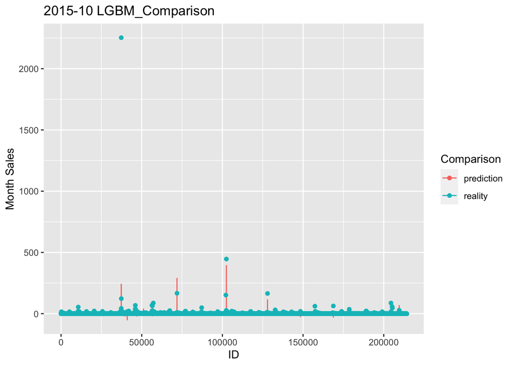

```r
Predict2 = y_test %>%
  transmute(
    ID = ID,
    reality = `2015-10`,
    y_hat =  predict(Regressor2,as.matrix(d2))
  )

MSE2 = mean((Predict2$reality - Predict2$y_hat)^2)
MAE2 = MAE(Predict2$reality, Predict2$y_hat)
RMSE2 = RMSE(Predict2$reality, Predict2$y_hat)

#結果呈現：2015-10實際資料與預測資料
ggplot(Predict2, aes(x= ID))+
  geom_line(aes(y = y_hat,colour = "prediction"))+
  geom_point(aes(y = reality,colour = "reality"))+
  labs(title = "2015-10 LGBM_Comparison",y = "Month Sales",colour = "Comparison")
```

## (三) Extreme Gradient Boosting

xgboost是大規模並行boosted tree的工具，過程中每顆樹都會對前一個模型損失函數進行二階泰勒展開擬合，最終結合多棵樹給出結果。XGBoost提供多種目標函數，包括回歸、分類或排序，因此可藉由調整函數達到期望的效果。

### 1.資料格式轉換

由於XGBoost自定義了一個數據矩陣類，會在模型訓練開始前對資料先進行預處理，以提高之後每次運算的迭代效率，因此須先將自料轉換為XGBoost的稀疏矩陣。

```r
library(xgboost)
#XGBoost-資料格式轉換
dtrain = xgb.DMatrix(data = as.matrix(train[,2:37]), label = train$`2015-10`)
dtest = xgb.DMatrix(data = as.matrix(test[,2:37]), label =  test$`2015-10`)
```

### 2.參數設定與調整

XGBoost參數眾多，主要可分為三種類型－一般參數、輔助參數及任務參數。

```r
xgb.params = list(
  booster = "gbtree", #指定要使用的上升模型，可選用上升模型gbtree或gblinear，前者須設定較多參數。分類問題需使用gbtree，而回歸問題則是兩者都可。
  gamma = 0.2,  # 控制剪枝的參數，越大越保守，一般介於0.1、0.2。
  max_depth = 16, # 樹的深度，越高表示越複雜，模型可發展越多，但易造成過度擬合。
  lambda = 3,  # 控制模型L2正則化的權重，用以避免模型過度擬合。
  subsample = 0.7, #對row的進行隨機抽樣，作為訓練樣本的比例。
  colsample_bytree = 0.7, #生成樹進行隨機抽樣的比例，越高表示每棵樹使用的col越多，會增加每棵小樹的複雜度
  min_child_weight = 3, # 在回歸中表示每個葉子的和最小值。用以避免過度擬合，越小越易造成過度擬合。
  eta = 0.05, #如同學習率，用以避免權重增加過快，該值越大模型愈保守
  objective = "reg:linear",  #指定學習類型，包括線性回歸、泊松回歸等。
  seed = 1000, #確保重現資料相同的輸出。
  eval_metric = "rmse" #衡量驗證資料之模型精準度。回歸模型多使用RMSE。
)
```

**在了解各參數代表意義後，尚需利用xgb.cv()，tune出最佳的nrounds，此參數用以控制最大迭代次數 根據圖形與計算結果，我們可得出最適的nrounds**

```r
#XGBoost-參數調整：使用xgb.cv()，tune出最佳的決策樹數量nrounds
cv.model = xgb.cv(
  params = xgb.params,
  data = dtrain,
  nfold = 5,     # 5-fold cv
  nrounds= 500,   # 測試1-500，各個樹總數下的模型
  # 如果當nrounds < 30 時，就已經有overfitting情況發生，那表示不用繼續tune下去了，可以提早停止
  early_stopping_rounds = 30,
  print_every_n = 20 # 每20個單位才顯示一次結果，
)
```

[output not shown]

```r
#XGBoost-參數調整結果
tmp = cv.model$evaluation_log
best.nrounds = cv.model$best_iteration
best.nrounds
```

```
## [1] 105
```

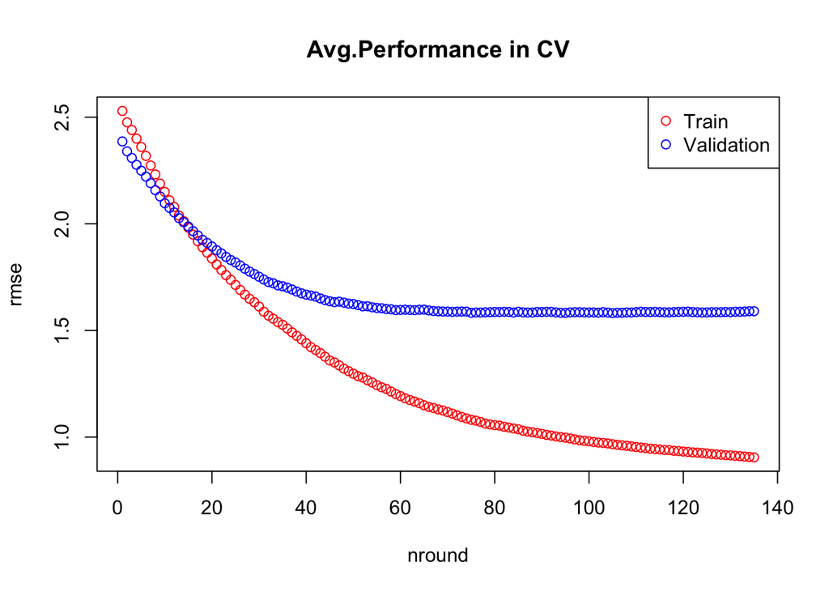

```r
#繪出參數調整結果
plot(x=1:nrow(tmp), y = tmp$train_rmse_mean, col='red', xlab="nround", ylab="rmse", main="Avg.Performance in CV")
points(x=1:nrow(tmp), y = tmp$test_rmse_mean, col='blue')
legend("topright", pch=1, col = c("red", "blue"),
       legend = c("Train", "Validation"))
```

### 3.建立模型

```r
Regressor3 = xgb.train(paras = xgb.params,
                       data = dtrain,
                       nrounds = best.nrounds)
```

```
## [22:18:10] WARNING: amalgamation/../src/learner.cc:573:
## Parameters: { "paras" } might not be used.
##
##   This may not be accurate due to some parameters are only used in language bindings but
##   passed down to XGBoost core.  Or some parameters are not used but slip through this
##   verification. Please open an issue if you find above cases.
```

### 4.模型運算

利用xgb.importance( )繪出各個變量的權重排名，此處取前六項。

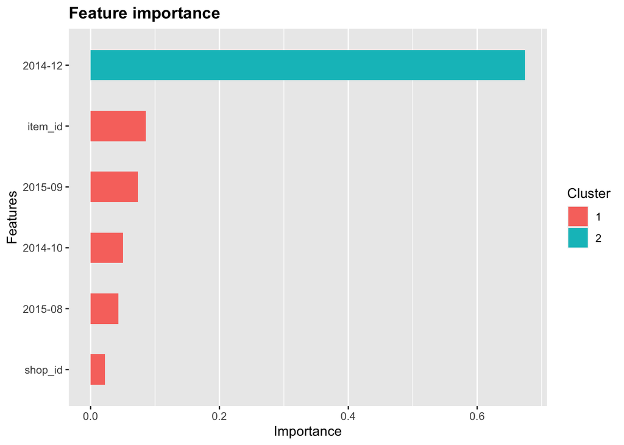

```r
#XGBoost-運算結果呈現：變數權重排名
xgb_importance = xgb.importance(feature_names=colnames(dtrain), model = Regressor3)
xgb.ggplot.importance(xgb_importance, top_n=6)
```

```r
#XGBoost-運算結果
summary3 = summary(Regressor3)
#summary3

Result3 = y_train %>%
  transmute(
    ID = ID,
    reality = `2015-10`,
    y_hat = predict(Regressor3, dtrain),
    residual = y_hat - reality,
    residual_square = residual^2)

SStot3 = sum((Result3$y_hat - mean(Result3$reality))^2)
SSresid3 = sum(Result3$residual_square)
R_square3 = (1 - SSresid3 / SStot3)
sprintf("percent variance explained, R^2: %1.1f%%", 100 * (1 - SSresid3 / SStot3))
```

```
## [1] "percent variance explained, R^2: 88.7%"
```

### 5.預測結果

繪出2015-10實際資料與預測資料之比較，紅色為預測結果，藍綠色為實際結果。

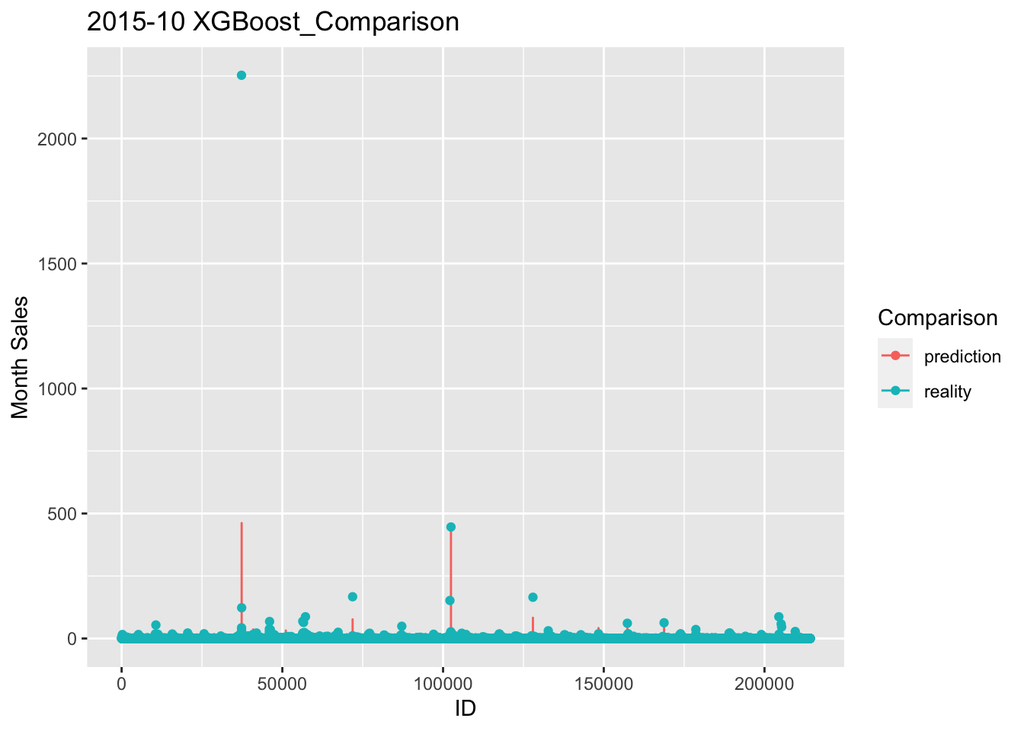

```r
Predict3 = y_test %>%
  transmute(
    ID = ID,
    reality = `2015-10`,
    y_hat = predict(Regressor3, dtest)
    )

MSE3 = mean((Predict3$reality - Predict3$y_hat)^2)
MAE3 = MAE(Predict3$reality, Predict3$y_hat)
RMSE3 = RMSE(Predict3$reality, Predict3$y_hat)

#XGBoost-預測結果呈現：2015-10實際資料與預測資料
ggplot(Predict3, aes(x= ID))+
  geom_line(aes(y = y_hat,colour = "prediction"))+
  geom_point(aes(y = reality,colour = "reality"))+
  labs(title = "2015-10 XGBoost_Comparison",y = "Month Sales",colour = "Comparison")
```

# 三、總結

## (一) 模型分析比較與問題探討

```r
Comparison = tibble(
  Model = c("LR","LGBM","XGB"),
  R_square = c(R_square1,R_square2,R_square3),
  MSE = c(MSE1,MSE2,MSE3),
  MAE = c(MAE1,MAE2,MAE3),
  RMSE = c(RMSE1,RMSE2,RMSE3)
)
kable(Comparison)
```

| Model | R_square | MSE | MAE | RMSE |
| --- | --- | --- | --- | --- |
| LR | 0.7138867 | 102.11046 | 0.4312421 | 10.104972 |
| LGBM | 0.8455301 | 92.91369 | 0.3871985 | 9.639175 |
| XGB | 0.8869039 | 111.85579 | 0.3714433 | 10.576190 |

將三個模型整體運算出結果進行比較，從各層面分析模型優劣，包含其效率、精准度、要求⋯⋯。

**II. 模型限制：**LR限制多。 根據上述於LR模型假設提到且運算出的統計值來看，雖模型運算結果尚可，然而並未符合其常態、獨立、同質性之假設。與其相比，LGBM、XGBoost皆僅需設定目標函數，便可直接進行運算。

**III. 運算效率：**LGBM較佳。 同1.所述， 除nrounds以外，較精準之XGBoost模型需要tune出其他參數值最適值，其所耗費時間極長，與之相比LGBM本身便加快了許多。

**IV. 佔用內存：**LGBM較佳。 LGBM所用的內存較XGB小，僅佔記憶體的1/8。

## (二) 未來運用

根據我們所算出資料可預期不同店家與品項之月銷量，以成本會計角度思考此資訊應可用於一店鋪之預算編列之參考以及進貨數量的依據。同時，我們可透過執行同樣的步驟以預測出未來銷售價格，銷量、售價資料搭配使用即可得出該月可能之營業額，若有其他資訊如該店每月店租、水電費等資料，也可藉此衡量該店的Breakeven point或是營運績效。因此，若能獲得相關預期資料，將可能減少不要的損失（如：過度囤貨卻遇到銷售淡季），提前為未來做準備。

## (三) 結論

此次報告中，主要著重在資料結構、資料視覺化與模型架設。其中前者利用到了許多dplyr中的函數，雖此套件是於學期的最後幾堂課才學習到，但在運用上真的非常簡易與方便，為我們節省不少理解函數的時間，使前期資料整理上輕鬆不少。另外此次報告也運用許多ggplot2的函數，對於簡易繪圖或是理解資料趨勢上實用性極高。

最後，我們參考了許多計量財務金融課程及數理統計所教授之知識以選擇、建立及訓練模型，進而盡可能對資料進行完整且精準的分析、檢定、模擬而達到最重要的目標–預測。

綜上，本次報告利用資料作為材料、程式作為工具，不僅將已知的知識融會貫通並產出完整的專案，更是讓我們了解如何實際的利用資料創造商業價值